# IPL Data Analysis & Match Outcome Prediction

Yukesh

2026-04-09

# 1 Introduction

## 1.1 Project Overview

The Indian Premier League (IPL) is the world’s most popular Twenty20 cricket league, played annually in India since 2008. This project performs a comprehensive data analysis of IPL matches from 2008 to 2024 and builds machine learning models to predict match outcomes.

## 1.2 Objectives

The key objectives of this project are:

- Explore and visualize IPL match data across 17 seasons
- Identify key patterns in team performance, toss decisions, and venue statistics
- Engineer meaningful features from raw match data
- Build and compare three machine learning models to predict which team wins a match
- Evaluate model performance and identify the most important predictive features

## 1.3 Dataset Description

Two datasets were used from Kaggle’s IPL Complete Dataset:

- **matches.csv** — 1,095 rows, one per match, covering season, teams, toss, venue, and result
- **deliveries.csv** — 260,920 rows, one per ball bowled, covering batsman, bowler, runs, and dismissals

# 2 Setup & Libraries

```r
library(tidyverse)
library(ggplot2)
library(dplyr)
library(readr)
library(caret)
library(rpart)
library(rpart.plot)
library(randomForest)
library(corrplot)
library(pROC)
```

# 3 Data Loading & Exploration

```r
matches    <- read_csv("../data/matches_clean.csv")
deliveries <- read_csv("../data/deliveries_clean.csv")

cat("Matches loaded   :", nrow(matches), "rows,", ncol(matches), "cols\n")
```

```
## Matches loaded   : 1090 rows, 18 cols
```

```r
cat("Deliveries loaded:", nrow(deliveries), "rows,", ncol(deliveries), "cols\n")
```

```
## Deliveries loaded: 260920 rows, 17 cols
```

## 3.1 Dataset Structure

```r
glimpse(matches)
```

```
## Rows: 1,090
## Columns: 18
## $ id              <dbl> 335982, 335983, 335984, 335985, 335986, 335987, 335988…
## $ season          <dbl> 2007, 2007, 2007, 2007, 2007, 2007, 2007, 2007, 2007, …
## $ city            <chr> "Bangalore", "Chandigarh", "Delhi", "Mumbai", "Kolkata…
## $ date            <date> 2008-04-18, 2008-04-19, 2008-04-19, 2008-04-20, 2008-…
## $ match_type      <chr> "League", "League", "League", "League", "League", "Lea…
## $ player_of_match <chr> "BB McCullum", "MEK Hussey", "MF Maharoof", "MV Bouche…
## $ venue           <chr> "M Chinnaswamy Stadium", "Punjab Cricket Association S…
## $ team1           <chr> "Royal Challengers Bengaluru", "Punjab Kings", "Delhi …
## $ team2           <chr> "Kolkata Knight Riders", "Chennai Super Kings", "Rajas…
## $ toss_winner     <chr> "Royal Challengers Bengaluru", "Chennai Super Kings", …
## $ toss_decision   <chr> "field", "bat", "bat", "bat", "bat", "bat", "bat", "fi…
## $ winner          <chr> "Kolkata Knight Riders", "Chennai Super Kings", "Delhi…
## $ result          <chr> "runs", "runs", "wickets", "wickets", "wickets", "wick…
## $ result_margin   <dbl> 140, 33, 9, 5, 5, 6, 9, 6, 3, 66, 7, 9, 10, 4, 13, 7, …
## $ target_runs     <dbl> 223, 241, 130, 166, 111, 167, 143, 209, 215, 183, 136,…
## $ target_overs    <dbl> 20, 20, 20, 20, 20, 20, 20, 20, 20, 20, 20, 20, 20, 20…
## $ super_over      <chr> "N", "N", "N", "N", "N", "N", "N", "N", "N", "N", "N",…
## $ toss_winner_won <chr> "No", "Yes", "No", "No", "No", "No", "No", "No", "Yes"…
```

## 3.2 Missing Values

```r
cat("Missing values in matches:\n")
```

```
## Missing values in matches:
```

```r
colSums(is.na(matches))
```

```
##              id          season            city            date      match_type
##               0               0               0               0               0
## player_of_match           venue           team1           team2     toss_winner
##               0               0               0               0               0
##   toss_decision          winner          result   result_margin     target_runs
##               0               0               0              14               0
##    target_overs      super_over toss_winner_won
##               0               0               0
```

# 4 Data Cleaning

```r
cat("Final cleaned dataset dimensions:\n")
```

```
## Final cleaned dataset dimensions:
```

```r
cat("Matches   :", nrow(matches), "rows,", ncol(matches), "cols\n")
```

```
## Matches   : 1090 rows, 18 cols
```

```r
cat("Deliveries:", nrow(deliveries), "rows,", ncol(deliveries), "cols\n")
```

```
## Deliveries: 260920 rows, 17 cols
```

# 5 Exploratory Data Analysis

## 5.1 Most Successful Teams

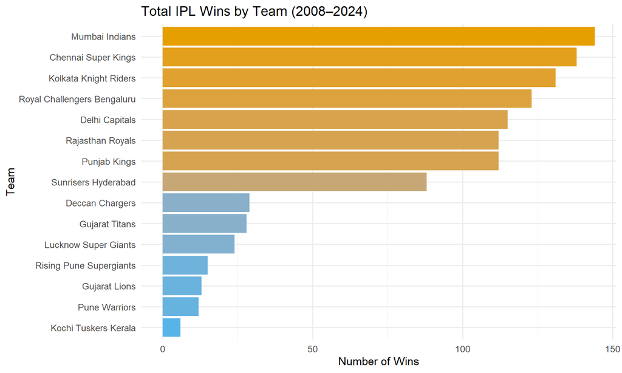

Total IPL wins by each team across all seasons

```r
team_wins <- matches %>%
  group_by(winner) %>%
  summarise(wins = n()) %>%
  arrange(desc(wins))

ggplot(team_wins, aes(x = reorder(winner, wins), y = wins, fill = wins)) +
  geom_col() +
  coord_flip() +
  scale_fill_gradient(low = "#56B4E9", high = "#E69F00") +
  labs(
    title = "Total IPL Wins by Team (2008–2024)",
    x = "Team", y = "Number of Wins"
  ) +
  theme_minimal(base_size = 13) +
  theme(legend.position = "none")
```

**Key Finding:** Mumbai Indians lead with 144 wins, followed closely by Chennai Super Kings (138) and Kolkata Knight Riders (131). These three teams form the “Big Three” of IPL.

## 5.2 Toss Decision Trend

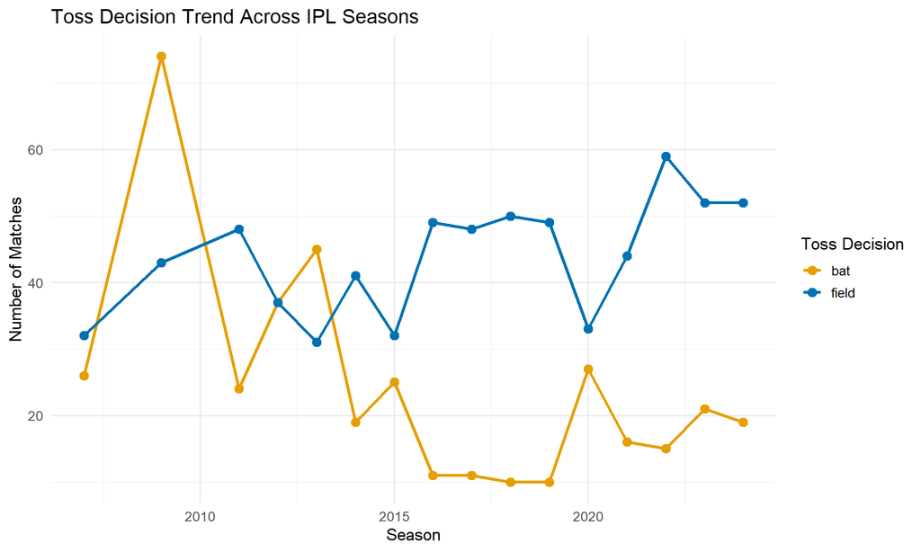

How toss decisions have changed across IPL seasons

```r
toss_trend <- matches %>%
  group_by(season, toss_decision) %>%
  summarise(count = n(), .groups = "drop")

ggplot(toss_trend,
       aes(x = season, y = count,
           color = toss_decision, group = toss_decision)) +
  geom_line(linewidth = 1.2) +
  geom_point(size = 3) +
  scale_color_manual(values = c("bat" = "#E69F00", "field" = "#0072B2")) +
  labs(
    title  = "Toss Decision Trend Across IPL Seasons",
    x = "Season", y = "Number of Matches", color = "Toss Decision"
  ) +
  theme_minimal(base_size = 13)
```

## 5.3 Does Toss Winning Help?

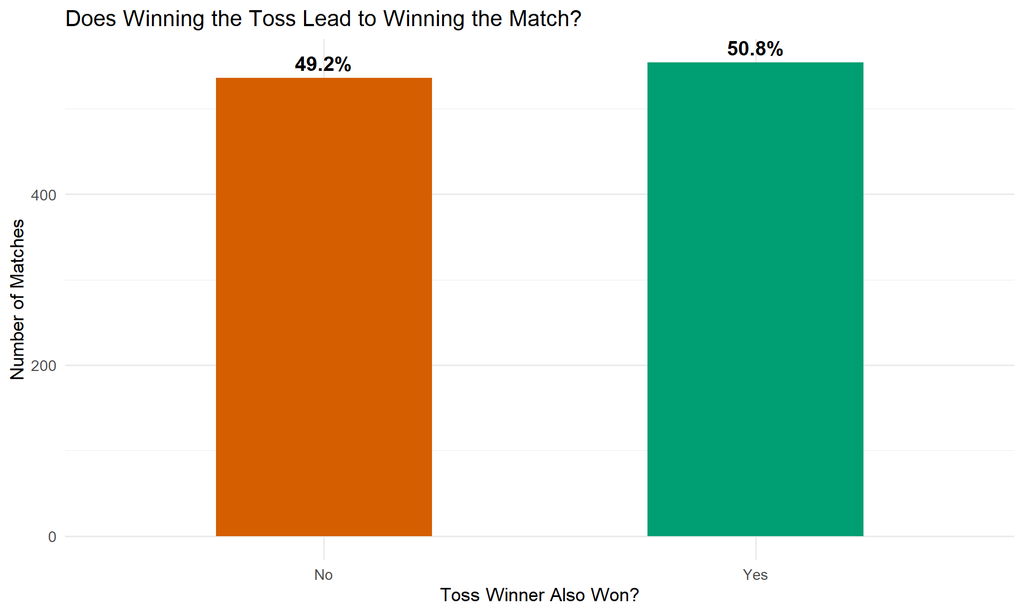

Relationship between winning the toss and winning the match

```r
toss_impact <- matches %>%
  group_by(toss_winner_won) %>%
  summarise(count = n()) %>%
  mutate(percentage = round(count / sum(count) * 100, 1))

ggplot(toss_impact,
       aes(x = toss_winner_won, y = count, fill = toss_winner_won)) +
  geom_col(width = 0.5) +
  geom_text(aes(label = paste0(percentage, "%")),
            vjust = -0.5, size = 5, fontface = "bold") +
  scale_fill_manual(values = c("Yes" = "#009E73", "No" = "#D55E00")) +
  labs(
    title = "Does Winning the Toss Lead to Winning the Match?",
    x = "Toss Winner Also Won?", y = "Number of Matches"
  ) +
  theme_minimal(base_size = 13) +
  theme(legend.position = "none")
```

**Key Finding:** Toss winners win only 50.8% of the time — barely above a coin flip. This confirms that the toss has minimal impact on match outcomes in modern IPL cricket.

## 5.4 Batting First vs Chasing

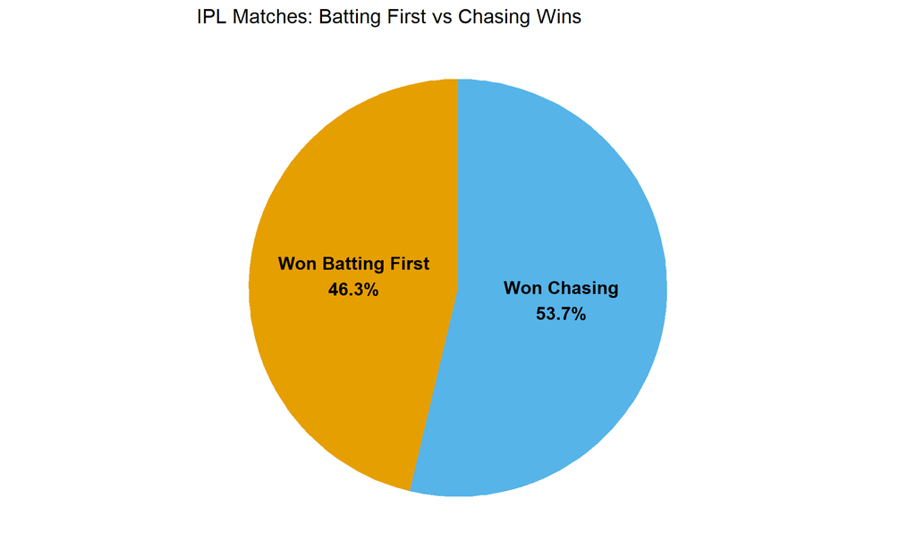

Distribution of wins by batting first versus chasing

```r
win_type <- matches %>%
  filter(result %in% c("runs", "wickets")) %>%
  group_by(result) %>%
  summarise(count = n()) %>%
  mutate(
    label      = ifelse(result == "runs",
                        "Won Batting First", "Won Chasing"),
    percentage = round(count / sum(count) * 100, 1)
  )

ggplot(win_type, aes(x = "", y = count, fill = label)) +
  geom_col(width = 1) +
  coord_polar(theta = "y") +
  geom_text(aes(label = paste0(label, "\n", percentage, "%")),
            position = position_stack(vjust = 0.5),
            size = 5, fontface = "bold") +
  scale_fill_manual(
    values = c("Won Batting First" = "#E69F00",
               "Won Chasing"       = "#56B4E9")) +
  labs(title = "IPL Matches: Batting First vs Chasing Wins") +
  theme_void(base_size = 13) +
  theme(legend.position = "none")
```

## 5.5 Top 10 Run Scorers

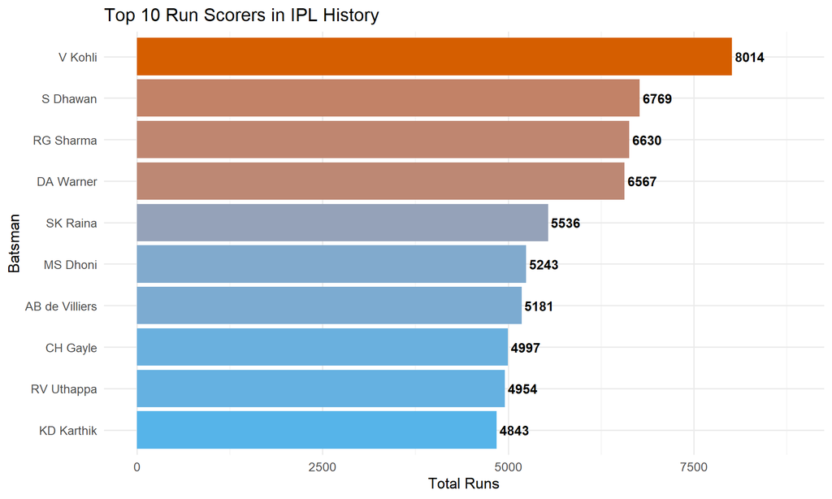

All-time top 10 run scorers in IPL history

```r
top_batsmen <- deliveries %>%
  group_by(batter) %>%
  summarise(total_runs = sum(batsman_runs)) %>%
  arrange(desc(total_runs)) %>%
  slice(1:10)

ggplot(top_batsmen,
       aes(x = reorder(batter, total_runs),
           y = total_runs, fill = total_runs)) +
  geom_col() +
  coord_flip() +
  geom_text(aes(label = total_runs),
            hjust = -0.1, size = 4, fontface = "bold") +
  scale_fill_gradient(low = "#56B4E9", high = "#D55E00") +
  labs(
    title = "Top 10 Run Scorers in IPL History",
    x = "Batsman", y = "Total Runs"
  ) +
  theme_minimal(base_size = 13) +
  theme(legend.position = "none") +
  ylim(0, max(top_batsmen$total_runs) * 1.1)
```

**Key Finding:** Virat Kohli leads with 8,014 runs — 1,245 runs ahead of second-placed Shikhar Dhawan (6,769).

## 5.6 Top 10 Wicket Takers

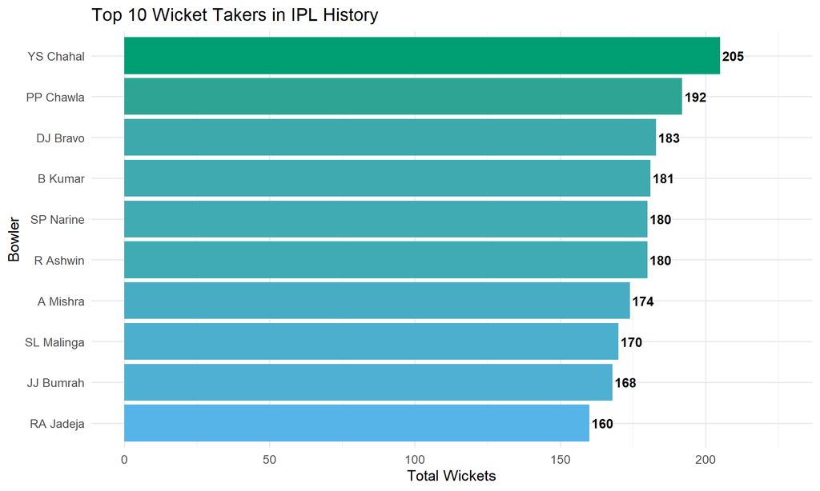

All-time top 10 wicket takers in IPL history

```r
top_bowlers <- deliveries %>%
  filter(is_wicket == 1) %>%
  filter(!dismissal_kind %in%
           c("run out", "retired hurt", "obstructing the field")) %>%
  group_by(bowler) %>%
  summarise(wickets = n()) %>%
  arrange(desc(wickets)) %>%
  slice(1:10)

ggplot(top_bowlers,
       aes(x = reorder(bowler, wickets),
           y = wickets, fill = wickets)) +
  geom_col() +
  coord_flip() +
  geom_text(aes(label = wickets),
            hjust = -0.1, size = 4, fontface = "bold") +
  scale_fill_gradient(low = "#56B4E9", high = "#009E73") +
  labs(
    title = "Top 10 Wicket Takers in IPL History",
    x = "Bowler", y = "Total Wickets"
  ) +
  theme_minimal(base_size = 13) +
  theme(legend.position = "none") +
  ylim(0, max(top_bowlers$wickets) * 1.1)
```

**Key Finding:** Yuzvendra Chahal leads with 205 wickets, confirming that leg-spin bowling dominates T20 cricket.

## 5.7 Matches Per Season

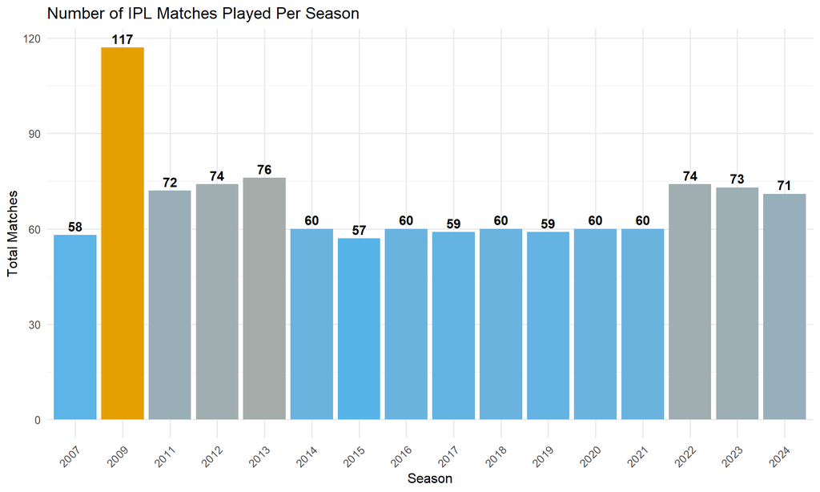

Growth of IPL season size over the years

```r
season_matches <- matches %>%
  group_by(season) %>%
  summarise(total_matches = n())

ggplot(season_matches,
       aes(x = factor(season), y = total_matches, fill = total_matches)) +
  geom_col() +
  geom_text(aes(label = total_matches),
            vjust = -0.4, size = 4, fontface = "bold") +
  scale_fill_gradient(low = "#56B4E9", high = "#E69F00") +
  labs(
    title = "Number of IPL Matches Played Per Season",
    x = "Season", y = "Total Matches"
  ) +
  theme_minimal(base_size = 12) +
  theme(
    axis.text.x = element_text(angle = 45, hjust = 1),
    legend.position = "none"
  )
```

## 5.8 Top 10 Venues

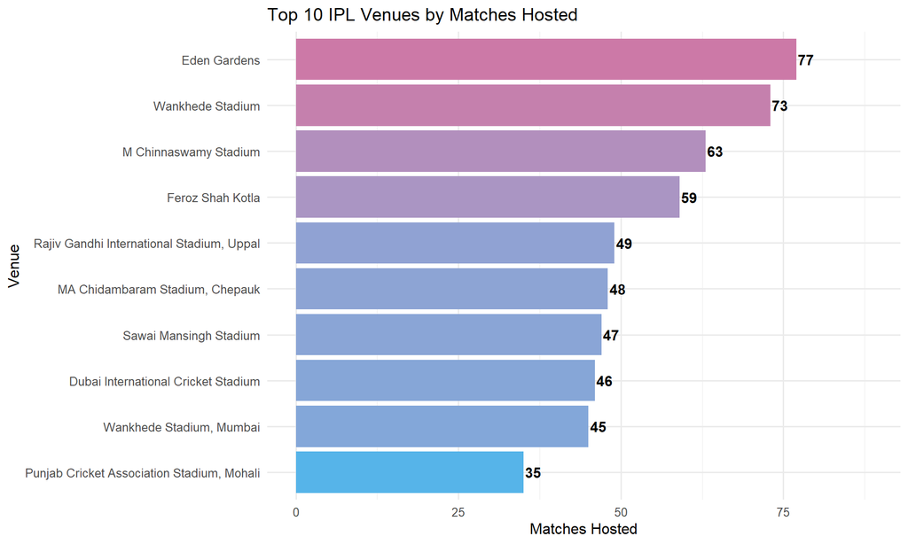

Most frequently used IPL venues

```r
top_venues <- matches %>%
  group_by(venue) %>%
  summarise(matches_hosted = n()) %>%
  arrange(desc(matches_hosted)) %>%
  slice(1:10)

ggplot(top_venues,
       aes(x = reorder(venue, matches_hosted),
           y = matches_hosted, fill = matches_hosted)) +
  geom_col() +
  coord_flip() +
  geom_text(aes(label = matches_hosted),
            hjust = -0.1, size = 4, fontface = "bold") +
  scale_fill_gradient(low = "#56B4E9", high = "#CC79A7") +
  labs(
    title = "Top 10 IPL Venues by Matches Hosted",
    x = "Venue", y = "Matches Hosted"
  ) +
  theme_minimal(base_size = 12) +
  theme(legend.position = "none") +
  ylim(0, max(top_venues$matches_hosted) * 1.15)
```

# 6 Feature Engineering

Eleven features were engineered from the raw data for the prediction model:

```r
# Rebuild all features
team_win_rate <- matches %>%
  pivot_longer(cols = c(team1, team2),
               names_to = "role", values_to = "team") %>%
  group_by(team) %>%
  summarise(
    total_matches = n(),
    total_wins    = sum(winner == team),
    win_rate      = round(total_wins / total_matches, 3)
  ) %>%
  arrange(desc(win_rate))

cat("Team Win Rates:\n")
```

```
## Team Win Rates:
```

```r
print(team_win_rate)
```

```
## # A tibble: 15 × 4
##    team                        total_matches total_wins win_rate
##    <chr>                               <int>      <int>    <dbl>
##  1 Gujarat Titans                         45         28    0.622
##  2 Chennai Super Kings                   237        138    0.582
##  3 Lucknow Super Giants                   43         24    0.558
##  4 Mumbai Indians                        261        144    0.552
##  5 Kolkata Knight Riders                 251        131    0.522
##  6 Rajasthan Royals                      219        112    0.511
##  7 Rising Pune Supergiants                30         15    0.5
##  8 Royal Challengers Bengaluru           252        123    0.488
##  9 Sunrisers Hyderabad                   182         88    0.484
## 10 Delhi Capitals                        250        115    0.46
## 11 Punjab Kings                          246        112    0.455
## 12 Gujarat Lions                          30         13    0.433
## 13 Kochi Tuskers Kerala                   14          6    0.429
## 14 Deccan Chargers                        75         29    0.387
## 15 Pune Warriors                          45         12    0.267
```

```r
all_teams     <- sort(unique(c(matches$team1, matches$team2)))
team_encoding <- setNames(1:length(all_teams), all_teams)
venue_counts  <- matches %>%
  group_by(venue) %>%
  summarise(venue_match_count = n())

model_features <- read_csv("../data/model_features.csv") %>%
  mutate(team1_wins = factor(team1_wins,
                             levels = c("Team2_Wins", "Team1_Wins")))

cat("\nModel features shape:",
    nrow(model_features), "rows,",
    ncol(model_features), "cols\n")
```

```
##
## Model features shape: 1090 rows, 12 cols
```

```r
cat("\nTarget variable distribution:\n")
```

```
##
## Target variable distribution:
```

```r
print(round(prop.table(table(model_features$team1_wins)) * 100, 1))
```

```
##
## Team2_Wins Team1_Wins
##       49.1       50.9
```

# 7 Machine Learning Models

## 7.1 Train-Test Split

```r
set.seed(42)
train_index <- createDataPartition(model_features$team1_wins,
                                   p = 0.80, list = FALSE)
train_data  <- model_features[ train_index, ]
test_data   <- model_features[-train_index, ]

cat("Training rows:", nrow(train_data), "\n")
```

```
## Training rows: 872
```

```r
cat("Testing rows :", nrow(test_data),  "\n")
```

```
## Testing rows : 218
```

## 7.2 Cross Validation Setup

```r
train_control <- trainControl(
  method          = "cv",
  number          = 10,
  savePredictions = TRUE,
  classProbs      = TRUE,
  summaryFunction = twoClassSummary
)
```

## 7.3 Model 1 — Logistic Regression

```r
set.seed(42)
model_lr <- train(
  team1_wins ~ ., data = train_data,
  method = "glm", family = "binomial",
  trControl = train_control, metric = "ROC"
)
pred_lr <- predict(model_lr, newdata = test_data)
cm_lr   <- confusionMatrix(pred_lr, test_data$team1_wins,
                            positive = "Team1_Wins")
acc_lr  <- round(cm_lr$overall["Accuracy"] * 100, 2)
cat("Logistic Regression Accuracy:", acc_lr, "%\n")
```

```
## Logistic Regression Accuracy: 53.67 %
```

## 7.4 Model 2 — Decision Tree

```r
set.seed(42)
model_dt <- train(
  team1_wins ~ ., data = train_data,
  method = "rpart", trControl = train_control,
  metric = "ROC", tuneLength = 10
)
pred_dt <- predict(model_dt, newdata = test_data)
cm_dt   <- confusionMatrix(pred_dt, test_data$team1_wins,
                            positive = "Team1_Wins")
acc_dt  <- round(cm_dt$overall["Accuracy"] * 100, 2)
cat("Decision Tree Accuracy:", acc_dt, "%\n")
```

```
## Decision Tree Accuracy: 55.5 %
```

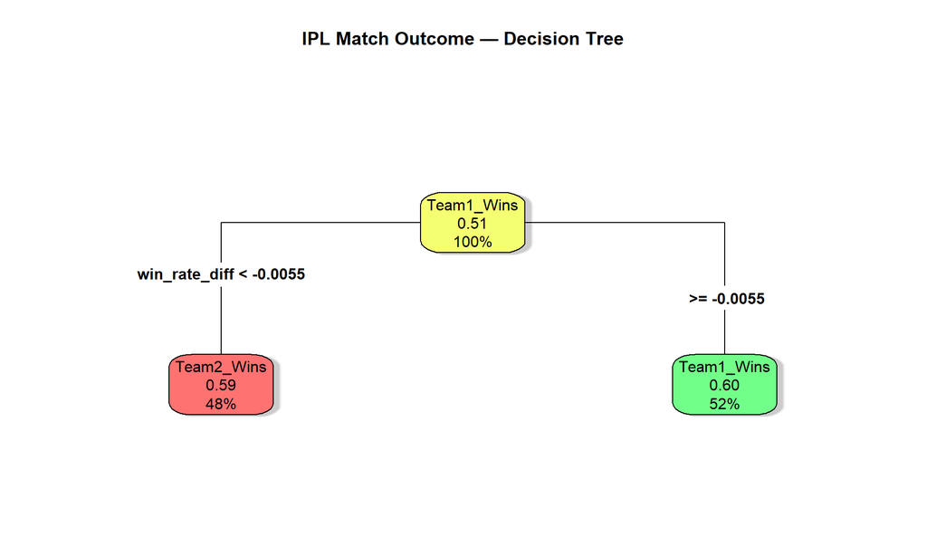

Decision Tree structure for IPL match prediction

```r
rpart.plot(
  model_dt$finalModel,
  type          = 4,
  extra         = 108,
  box.palette   = "RdYlGn",
  shadow.col    = "gray80",
  fallen.leaves = TRUE,
  main          = "IPL Match Outcome — Decision Tree"
)
```

## 7.5 Model 3 — Random Forest

```r
set.seed(42)
model_rf <- train(
  team1_wins ~ ., data = train_data,
  method = "rf", trControl = train_control,
  metric = "ROC", tuneLength = 5, ntree = 500
)
pred_rf <- predict(model_rf, newdata = test_data)
cm_rf   <- confusionMatrix(pred_rf, test_data$team1_wins,
                            positive = "Team1_Wins")
acc_rf  <- round(cm_rf$overall["Accuracy"] * 100, 2)
cat("Random Forest Accuracy:", acc_rf, "%\n")
```

```
## Random Forest Accuracy: 51.83 %
```

# 8 Model Evaluation

## 8.1 Accuracy Comparison

```r
model_comparison <- data.frame(
  Model    = c("Logistic Regression", "Decision Tree", "Random Forest"),
  Accuracy = c(acc_lr, acc_dt, acc_rf),
  Sensitivity = c(
    round(cm_lr$byClass["Sensitivity"] * 100, 2),
    round(cm_dt$byClass["Sensitivity"] * 100, 2),
    round(cm_rf$byClass["Sensitivity"] * 100, 2)
  ),
  Specificity = c(
    round(cm_lr$byClass["Specificity"] * 100, 2),
    round(cm_dt$byClass["Specificity"] * 100, 2),
    round(cm_rf$byClass["Specificity"] * 100, 2)
  )
)

print(model_comparison)
```

```
##                 Model Accuracy Sensitivity Specificity
## 1 Logistic Regression    53.67       56.76       50.47
## 2       Decision Tree    55.50       60.36       50.47
## 3       Random Forest    51.83       43.24       60.75
```

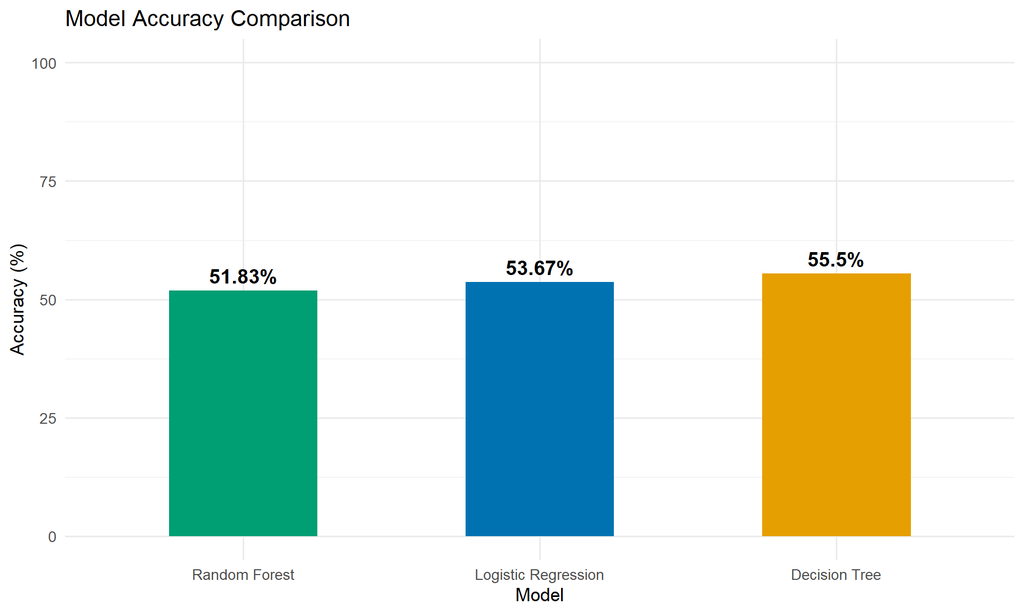

Accuracy comparison across all three models

```r
ggplot(model_comparison,
       aes(x = reorder(Model, Accuracy),
           y = Accuracy, fill = Model)) +
  geom_col(width = 0.5) +
  geom_text(aes(label = paste0(Accuracy, "%")),
            vjust = -0.5, size = 5, fontface = "bold") +
  scale_fill_manual(values = c(
    "Logistic Regression" = "#0072B2",
    "Decision Tree"       = "#E69F00",
    "Random Forest"       = "#009E73"
  )) +
  labs(
    title = "Model Accuracy Comparison",
    x = "Model", y = "Accuracy (%)"
  ) +
  theme_minimal(base_size = 13) +
  theme(legend.position = "none") +
  ylim(0, 100)
```

## 8.2 Feature Importance

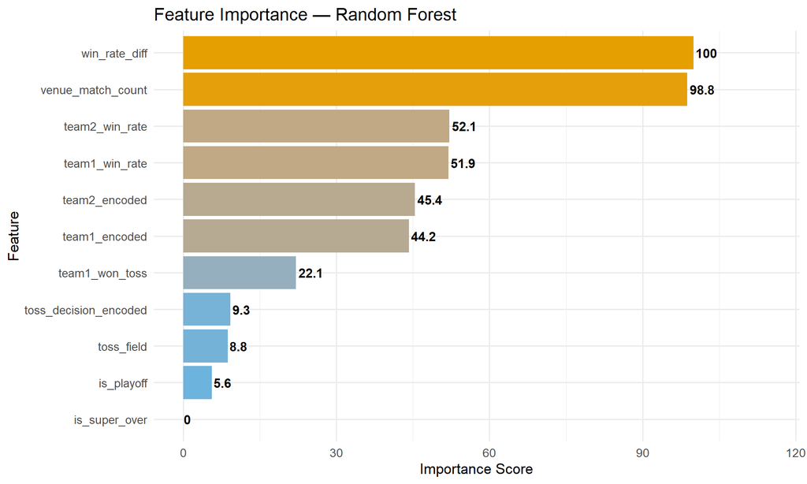

Most important features according to Random Forest

```r
importance_df <- varImp(model_rf)$importance %>%
  as.data.frame() %>%
  rownames_to_column("feature") %>%
  arrange(desc(Overall))

ggplot(importance_df,
       aes(x = reorder(feature, Overall),
           y = Overall, fill = Overall)) +
  geom_col() +
  coord_flip() +
  scale_fill_gradient(low = "#56B4E9", high = "#E69F00") +
  geom_text(aes(label = round(Overall, 1)),
            hjust = -0.1, size = 4, fontface = "bold") +
  labs(
    title = "Feature Importance — Random Forest",
    x = "Feature", y = "Importance Score"
  ) +
  theme_minimal(base_size = 13) +
  theme(legend.position = "none") +
  ylim(0, max(importance_df$Overall) * 1.15)
```

## 8.3 ROC Curve

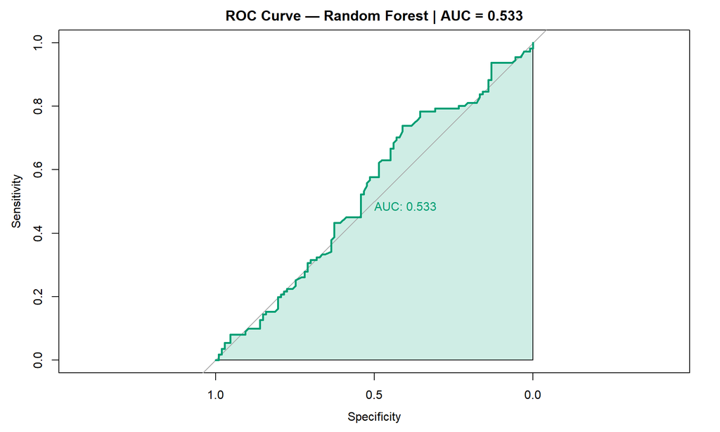

ROC Curve for Random Forest model

```r
library(pROC)
pred_rf_prob <- predict(model_rf, newdata = test_data, type = "prob")
roc_rf <- roc(
  response  = test_data$team1_wins,
  predictor = pred_rf_prob[, "Team1_Wins"],
  levels    = c("Team2_Wins", "Team1_Wins")
)
plot(roc_rf,
     col             = "#009E73",
     lwd             = 2.5,
     main            = paste("ROC Curve — Random Forest | AUC =",
                             round(auc(roc_rf), 3)),
     print.auc       = TRUE,
     auc.polygon     = TRUE,
     auc.polygon.col = "#009E7330")
```

# 9 Key Findings & Conclusions

## 9.1 Summary of Findings

| Finding | Insight |
| --- | --- |
| Most wins | Mumbai Indians — 144 wins |
| Best win rate | Gujarat Titans — 62.2% |
| Toss impact | Only 50.8% — nearly random |
| Fielding first preference | 64% of toss winners chose to field |
| Top batsman | Virat Kohli — 8,014 runs |
| Top bowler | YS Chahal — 205 wickets |
| Most used venue | Eden Gardens — 77 matches |
| Best model | Decision Tree — 55.50% accuracy |
| Top feature | Win rate difference — Score 100 |

## 9.2 Model Performance Discussion

- Cricket is inherently unpredictable — upsets are frequent
- Only 11 pre-match features were used — no live ball-by-ball data
- Professional cricket analytics systems use real-time data and achieve 80–85% accuracy using in-match features like current score and wickets fallen

## 9.3 Limitations

1. **No live match data** — only pre-match features used
2. **Venue name mismatches** — some newer venues not found in dataset (e.g. Narendra Modi Stadium)
3. **Retired teams** — Pune Warriors and Kochi Tuskers Kerala have very few matches, affecting their win rate reliability
4. **Team composition changes** — same team name across years can have very different squads

## 9.4 Future Improvements

1. Add **ball-by-ball live features** like powerplay score and wickets to significantly improve accuracy
2. Use **player availability** and recent form as features
3. Apply **deep learning** models like LSTM for sequence-based match prediction
4. Build a **Shiny web app** for interactive match prediction

# 10 Conclusion

This project successfully performed end-to-end IPL data analysis covering data loading, cleaning, exploratory analysis, feature engineering, and machine learning model building. Three models were trained and compared — Decision Tree emerged as the best performer with **55.50% accuracy**.

The analysis revealed that **team historical strength** (win rate difference) and **venue familiarity** are the strongest predictors of match outcomes, while toss results have minimal impact. Virat Kohli and Yuzvendra Chahal stand out as the greatest individual performers in IPL history.

*Report generated using R 4.5.3 | Subject: R for Data Science*